# Portfolio_04

# 2. Residual analysis

The residuals of the selected model appear to pass the assumptions of a linear model. Therefore the model is correctly specified. The residual vs fitted plot shows a more or less horizontal trend. Validating the linearity assumption. In the residuals vs fitted and scale and location plots the randomly distributed residuals with no funneling indicate homoscedasticity. Validating the assumption of equal variance.  
The QQ plot seems to indicate normally distributed residuals. There is some departure towards the top end of the plot, but this is not major and could be an artefact of random noise in the data.

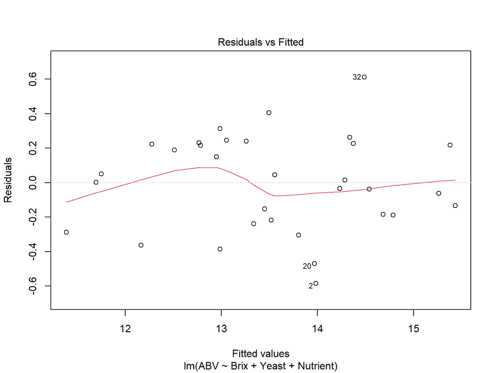

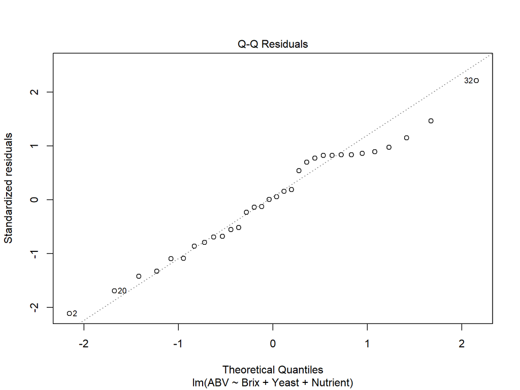

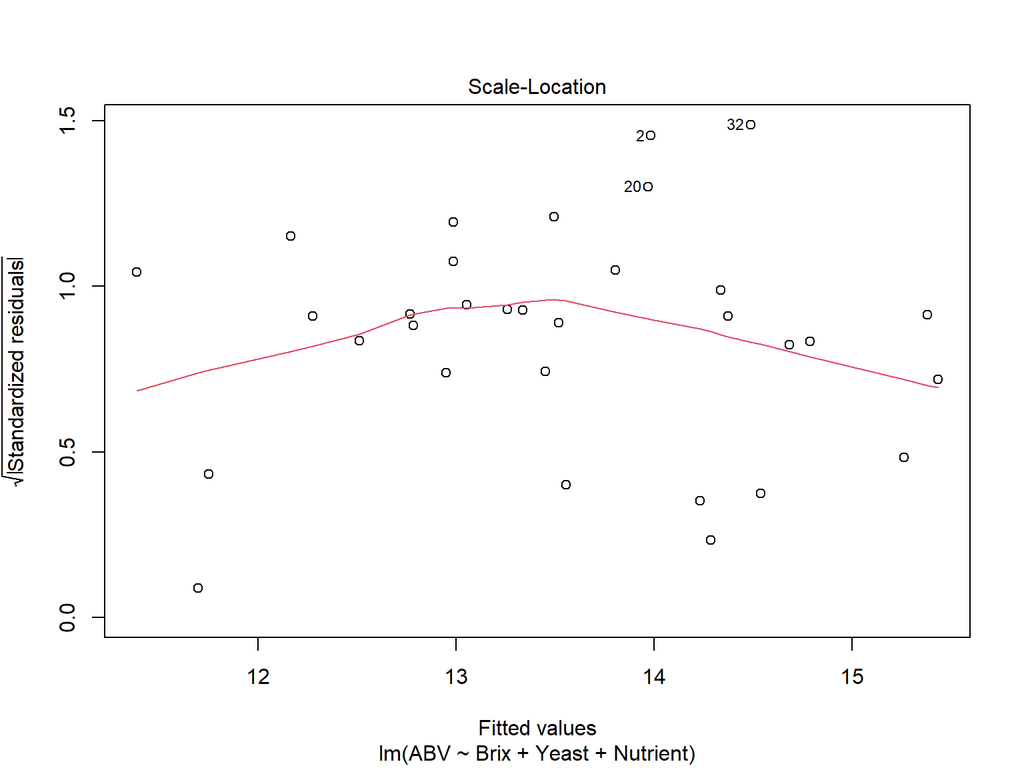

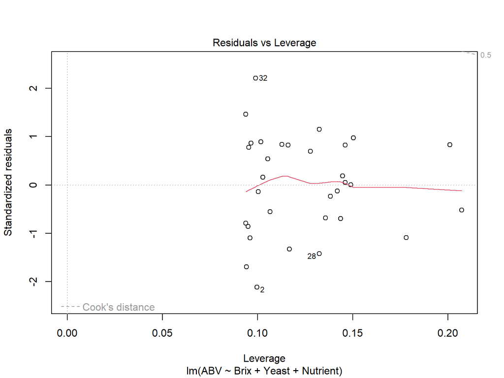

```r
plot(Wine.lm2)
```